# 6306: Week 10 FLS

Matt Farrow

10/26/2020

## Question 1: Model Interpretation

Using the cars.csv dataset,

### Fit the Model $mpg = β_0 + β_1(Weight) + 𝜀$

```r
# Read in the data
cars <- read_csv(here::here("6306", "week 10", "cars.csv"))

# Create the model
cars_model <- lm(MPG ~ Weight, data = cars)

# Generate the model summary
summary(cars_model)
```

```
##
## Call:
## lm(formula = MPG ~ Weight, data = cars)
##
## Residuals:
##      Min       1Q   Median       3Q      Max
## -12.0008  -2.7684  -0.3342   2.1245  16.4920
##
## Coefficients:
##               Estimate Std. Error t value Pr(>|t|)
## (Intercept) 46.2734424  0.7974987   58.02   <2e-16 ***
## Weight      -0.0076613  0.0002577  -29.73   <2e-16 ***
## ---
## Signif. codes:  0 '***' 0.001 '**' 0.01 '*' 0.05 '.' 0.1 ' ' 1
##
## Residual standard error: 4.332 on 392 degrees of freedom
## Multiple R-squared:  0.6927, Adjusted R-squared:  0.6919
## F-statistic: 883.6 on 1 and 392 DF,  p-value: < 2.2e-16
```

### 6-Step Hypothesis Test

Conduct a 6-step hypothesis test of the slope. That is, test the claim that the slope is significantly different from zero. Show all 6 steps and quantify your uncertainty by including a 95% confidence interval for the slope.

```r
# Critical values
qt(1-0.05, 392)
```

```
## [1] 1.64875
```

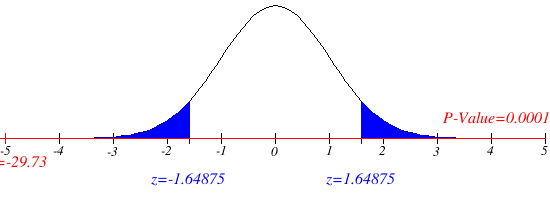

```r
knitr::include_graphics(here::here("6306", "week 10", "norm.gif"))
```

3. Calculate the t-statistic
- -29.73
4. Calculate the p-value
- <2e-16
5. Make a decision
- Reject the NULL hypothesis
6. Write a clear conclusion
- There is overwhelming evidence to suggest that the slope is different than 0 (p-value = 2e-16). 95% confidence interval (-0.0082, -0.0072).

Describe the relationship between miles per gallon and the weight of the car by interpreting the slope parameter. Again, be sure and include a 95% confidence interval in your interpretation.

```r
summary(cars_model)
```

```
##
## Call:
## lm(formula = MPG ~ Weight, data = cars)
##
## Residuals:
##      Min       1Q   Median       3Q      Max
## -12.0008  -2.7684  -0.3342   2.1245  16.4920
##
## Coefficients:
##               Estimate Std. Error t value Pr(>|t|)
## (Intercept) 46.2734424  0.7974987   58.02   <2e-16 ***
## Weight      -0.0076613  0.0002577  -29.73   <2e-16 ***
## ---
## Signif. codes:  0 '***' 0.001 '**' 0.01 '*' 0.05 '.' 0.1 ' ' 1
##
## Residual standard error: 4.332 on 392 degrees of freedom
## Multiple R-squared:  0.6927, Adjusted R-squared:  0.6919
## F-statistic: 883.6 on 1 and 392 DF,  p-value: < 2.2e-16
```

```r
confint(cars_model)
```

```
##                    2.5 %       97.5 %
## (Intercept) 44.705532760 47.841351974
## Weight      -0.008168061 -0.007154609
```

$MPG = 46.2734 - 0.0077(Weight)$

## Question 2: Leave One Out Cross Validation

Using the cars.csv, conduct an internal n-fold (leave one out) cross validation of the following SLR models:

1. Model 1: $mpg = β_0 + β_1(Weight) + 𝜀$

```r
library(caret)

train(MPG ~ Weight, method = "lm", data = cars, trControl = trainControl(method = "LOOCV"))
```

```
## Linear Regression
##
## 394 samples
##   1 predictor
##
## No pre-processing
## Resampling: Leave-One-Out Cross-Validation
## Summary of sample sizes: 393, 393, 393, 393, 393, 393, ...
## Resampling results:
##
##   RMSE      Rsquared   MAE
##   4.341388  0.6898278  3.295356
##
## Tuning parameter 'intercept' was held constant at a value of TRUE
```

2. Model 2: $mpg = β_0 + β_1(Weight) + β_2(Weight)^2 + 𝜀$

```r
train(MPG ~ Weight + I(Weight^2), method = "lm", data = cars, trControl = trainControl(method = "LOOCV"))
```

```
## Linear Regression
##
## 394 samples
##   1 predictor
##
## No pre-processing
## Resampling: Leave-One-Out Cross-Validation
## Summary of sample sizes: 393, 393, 393, 393, 393, 393, ...
## Resampling results:
##
##   RMSE      Rsquared   MAE
##   4.187032  0.7114922  3.077807
##
## Tuning parameter 'intercept' was held constant at a value of TRUE
```

3. Which model is favored by this cross validation?
- Model 2 is favored by cross-validation.
4. Describe the relationship between miles per gallon and the weight of the car (if it has changed) (again making sure to quantify any uncertainty you may have.)
5. Use the favored model to estimate the mean mpg of cars that weigh 2000 lbs.

```r
# Using model 2 let's estimate the mean mpg of the sub-population of cars that weigh 2000lbs
fit <- lm(MPG ~ Weight + I(Weight^2), data = cars)
car2000 <- data.frame(Weight = 2000)
car2000_conf <- predict(fit, newdata = car2000, interval = "confidence")
car2000_conf
```

```
##        fit      lwr      upr
## 1 32.07914 31.33136 32.82691
```

```r
# Using model 2 let's estimate the mpg of an individual car that weighs 2000lbs
fit <- lm(MPG ~ Weight + I(Weight^2), data = cars)
car2000 <- data.frame(Weight = 2000)
car2000_pred <- predict(fit, newdata = car2000, interval = "prediction")
car2000_pred
```

```
##        fit      lwr      upr
## 1 32.07914 23.83259 40.32569
```

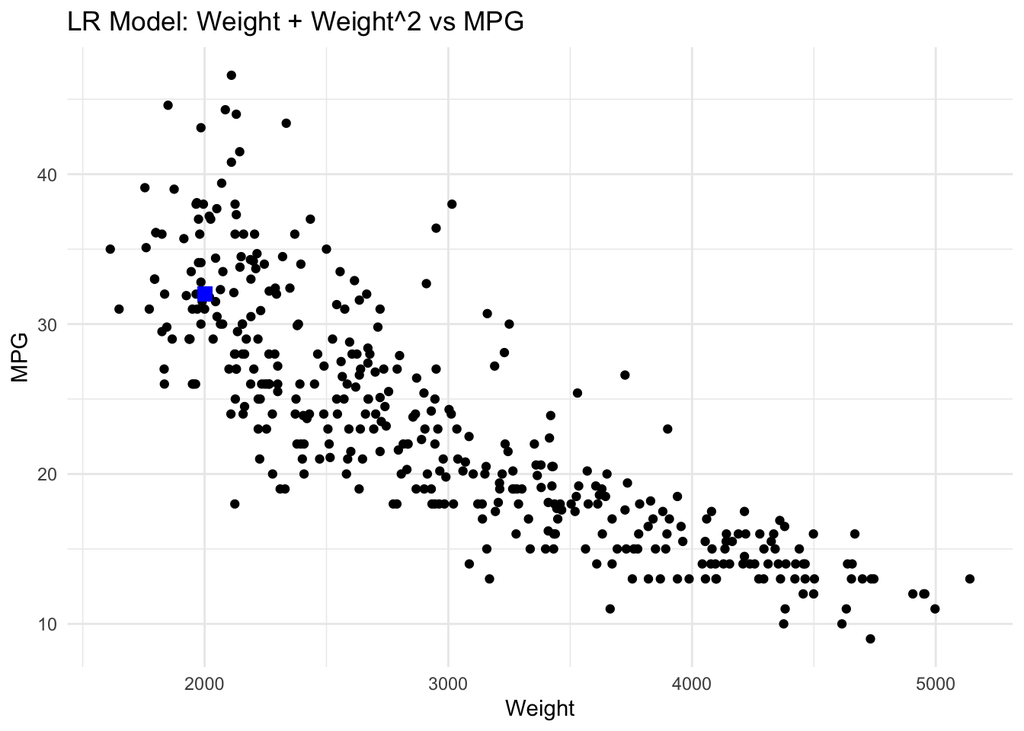

```r
# Plot predicted mean on our graph
cars %>% ggplot(aes(x = Weight, y = MPG)) +
  geom_point() +
  # geom_line(data = cars, aes(x = Weight, y = car2000_pred, col = "red", size = 1)) +
  ggtitle("LR Model: Weight + Weight^2 vs MPG") +
  scale_color_discrete(name = "Predicted") +
  geom_point(aes(x = 2000, y = floor(car2000_pred[1])), color = "blue", shape = "square", size = 3) +
  theme_minimal()
```

## Question 3: Impute Values

Using the cars.csv dataset, We would like to assess the relationship (interpret slope parameter) between mpg and horsepower. Notice that some of the horsepower values are missing.

1. Impute (predict and insert) the missing horsepower values by fitting a regression model.
2. You may use any of the variables as regressors EXCEPT for MPG (since we will later be using horsepower to predict mpg.)
3. Assess the relationship between the mpg and the slope. Make sure and include estimates of your uncertainty (i.e. Confidence intervals.)
4. Use your model and imputed data to estimate the mean mpg for a car with 250 horsepower.

```r
# How many missing values?
colSums(is.na(cars))
```

```
##        Model          MPG    Cylinders Displacement   Horsepower       Weight
##            0            0            0            0            2            0
## Acceleration         Year       Origin
##            0            0            0
```

```r
missingIdx <- which(is.na(cars$Horsepower))

# Look at the rows with missing values
cars %>% filter(is.na(Horsepower))
```

```
## # A tibble: 2 x 9
##   Model   MPG Cylinders Displacement Horsepower Weight Acceleration  Year Origin
##   <chr> <dbl>     <dbl>        <dbl>      <dbl>  <dbl>        <dbl> <dbl> <chr>
## 1 rena…  34.5         4          100         NA   2320         15.8    81 Europe
## 2 amc …  23           4          151         NA   3035         20.5    82 US
```

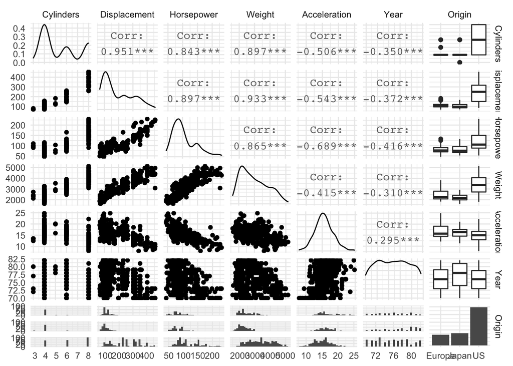

```r
# Look at variable relationships
cars %>%
  select(-c(1:2)) %>%
  ggpairs() +
  theme_minimal()
```

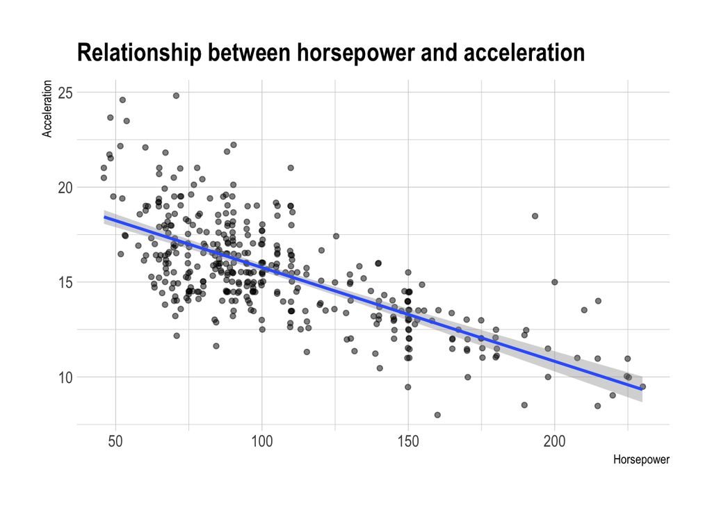

```r
# Look at horsepower and acceleration
cars %>%
  ggplot(aes(Horsepower, Acceleration)) +
  geom_jitter(alpha = 0.5) +
  geom_smooth(method = "lm") +
  labs(title = "Relationship between horsepower and acceleration") +
  theme_ipsum()
```

```r
# Fit a model using acceleration
fit <- lm(Horsepower ~ Acceleration, data = cars)
summary(fit)
```

```
##
## Call:
## lm(formula = Horsepower ~ Acceleration, data = cars)
##
## Residuals:
##     Min      1Q  Median      3Q     Max
## -65.598 -17.713  -2.463  17.873 116.980
##
## Coefficients:
##              Estimate Std. Error t value Pr(>|t|)
## (Intercept)  253.9074     8.0796   31.43   <2e-16 ***
## Acceleration  -9.6155     0.5119  -18.78   <2e-16 ***
## ---
## Signif. codes:  0 '***' 0.001 '**' 0.01 '*' 0.05 '.' 0.1 ' ' 1
##
## Residual standard error: 27.93 on 390 degrees of freedom
##   (2 observations deleted due to missingness)
## Multiple R-squared:  0.475,  Adjusted R-squared:  0.4736
## F-statistic: 352.8 on 1 and 390 DF,  p-value: < 2.2e-16
```

```r
confint(fit)
```

```
##                  2.5 %     97.5 %
## (Intercept)  238.02240 269.792487
## Acceleration -10.62195  -8.609106
```

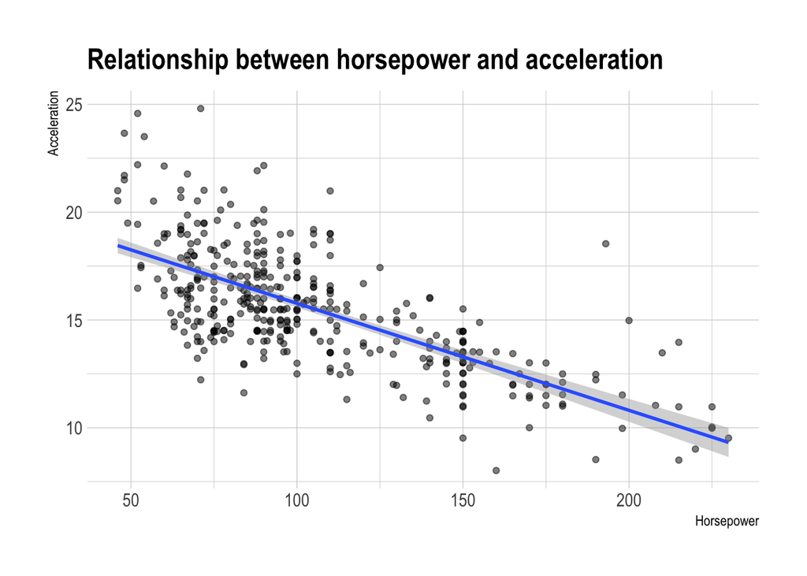

```r
# Predict missing horsepower values using acceleration
cars_predict <- predict(fit, newdata = tibble(Acceleration = c(cars[missingIdx[1], ]$Acceleration,
                                                               cars[missingIdx[2], ]$Acceleration)))

# Add predictions to cars
cars[missingIdx[1], ]$Horsepower <- cars_predict[1]
cars[missingIdx[2], ]$Horsepower <- cars_predict[2]

# Look at the relationship with imputed values
# Look at horsepower and acceleration
cars %>%
  ggplot(aes(Horsepower, Acceleration)) +
  geom_jitter(alpha = 0.5) +
  geom_smooth(method = "lm") +
  labs(title = "Relationship between horsepower and acceleration") +
  theme_ipsum()
```

```r
# Re-run the model
fit <- lm(Horsepower ~ Acceleration, data = cars)
summary(fit)
```

```
##
## Call:
## lm(formula = Horsepower ~ Acceleration, data = cars)
##
## Residuals:
##     Min      1Q  Median      3Q     Max
## -65.598 -17.646  -2.405  17.825 116.980
##
## Coefficients:
##              Estimate Std. Error t value Pr(>|t|)
## (Intercept)  253.9074     8.0329   31.61   <2e-16 ***
## Acceleration  -9.6155     0.5085  -18.91   <2e-16 ***
## ---
## Signif. codes:  0 '***' 0.001 '**' 0.01 '*' 0.05 '.' 0.1 ' ' 1
##
## Residual standard error: 27.85 on 392 degrees of freedom
## Multiple R-squared:  0.477,  Adjusted R-squared:  0.4757
## F-statistic: 357.6 on 1 and 392 DF,  p-value: < 2.2e-16
```

```r
confint(fit)
```

```
##                  2.5 %     97.5 %
## (Intercept)  238.11448 269.700405
## Acceleration -10.61524  -8.615814
```

```r
# MSE
mean(cars$Horsepower - (predict(cars_model)^2))
```

```
## [1] -488.7229
```

```r
# Predict mean mpg for car with 250 HP
fit <- lm(MPG ~ Horsepower, data = cars)
horse_predict <-
  predict(fit,
          newdata = data.frame(Horsepower = 250),
          interval = "confidence")
horse_predict
```

```
##         fit    lwr      upr
## 1 0.5701486 -1.348 2.488297
```

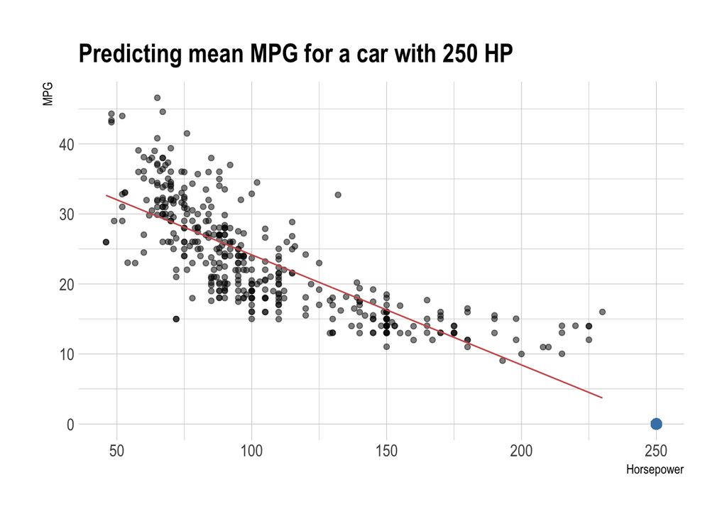

```r
# Plot predicted mean on our graph
cars %>%
  ggplot(aes(Horsepower, MPG)) +
  geom_jitter(alpha = 0.5) +
  geom_line(data = cars, aes(Horsepower, predict(fit)), color = "indianred") +
  geom_point(aes(250, floor(horse_predict[1])),
             color = "steelblue",
             size = 3) +
  labs(title = "Predicting mean MPG for a car with 250 HP") +
  theme_ipsum()
```